# act_report

## Report: act_report

- Create a **250-word-minimum written report** called "act_report.pdf" or "act_report.html" that communicates the insights and displays the visualization(s) produced from your wrangled data. This is to be framed as an external document, like a blog post or magazine article, for example.

### Analyzing @WeRateDogs Twitter user data

WeRateDogs is a Twitter user that rates people's dogs with a humorous comment about the dog. These ratings almost always have a denominator of 10. The numerator though, is almost always greater than 10. For example, there are dogs that will have comments with rating 11/10, 25/10, 150/10, etc. These ratings are being given by users and the reason for this type of ratings is because "they are good dog Brent". WeRateDogs has over 40 million followers and has received international media coverage.

### Gathering of data and wrangling process

Much of the data was downloaded and emailed directly on request from Twitter company. There were over 5000+ tweets in this archied dataset that was sent. To have a complete dataset to work with, more data was download via a Tweeter developer account. The wrangling process included cleaning of incorrect data types, dealing with inapproriate and inconsistent values, handling of null values, unpivoting of columns to rows and merging of some dataset to have a tidy dataset that meets the tidy dataset requirements as suggested by Hadley Wickham, the creator of the [tidy dataset](https://cran.r-project.org/web/packages/tidyr/vignettes/tidy-data.html) format.

### Analysis and Visualizations

After getting a tidy master dataset, some analysis we made through various exploratory data analysis processes. We exermined relationships between variables to see how they relate.

|  | stage_name | stage | favorite_count |
| --- | --- | --- | --- |
| 0 | doggo | doggo | 15408.440678 |
| 1 | floofer | floofer | 18359.250000 |
| 2 | pupper | pupper | 15668.319149 |
| 3 | puppo | puppo | 25657.166667 |

Looking at the average, relative to the count of each dog stage, we see that dogs identified as puppo were more favorited, with dogs identified as doggo being least favorited.

|  | stage_name | stage | retweet_count |
| --- | --- | --- | --- |
| 0 | doggo | doggo | 59 |
| 1 | floofer | floofer | 4 |
| 2 | pupper | pupper | 47 |
| 3 | puppo | puppo | 18 |

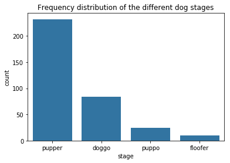